# Python Intro

19.02.2024

Hannah Busshoff, M.Sc.

# Outline

1. Why you should learn Python (even in times of ChatGPT)!
2. Basic syntax and data types
3. Python packages
   - numpy

# What is Python?

- Python is a programming language.
- It was created by Guido von Rossum and has been around since 1989.
- Nowadays, Python is the leading language in *data science*, *machine learning*, and *AI development*.

[figure not shown]

Advantages of Python in a nutshell:

1. Easy to Learn.
2. Free.
3. Portable (Windows, Mac, Linux…).
4. Big community and hence MANY libraries and extensions, learning resources.
5. Focus on readability and productivity.
6. Extensible (C/C++).

# Why should you learn Python?

1. *Coding Skills*: (data types, smart coding, debugging, object-oriented programming) - also still required a lot in quantitative jobs
2. *Understanding ML/AI Models and customize*
3. *You may be on your own* due to privacy concerns or regulatory requirements

...

# Basic Syntax

# Comments

Single line comments start with a hashtag.

```python
# This a single line comment
```

```python
# I am tired.
```

```python
"""This is a
   comment, which extends over multiple lines."""
```

```
'This is a \n   comment, which extends over multiple lines.'
```

# Basic Data Types

1. Numbers
   - integer
   - float
2. Boolean
3. String
4. Lists
5. Tuples
6. Dictionaries

# Numbers

1. integer

```python
#hannah = 28
hannah = int(28)
type(hannah)
```

```
int
```

1. float

```python
pi = 3.14159
pi = float(3.14159)
```

Nice to know. We can assign two or more variables simultaneously

```python
hannah, jessica, fabian = 28, 28, 29
```

Print out data.

```python
print(f"Hannah is {hannah}. Jessica is {jessica}. Fabian is {fabian}.")
```

```
Hannah is 28. Jessica is 28. Fabian is 29.
```

# Number expressions

Assigning a value

```python
a = 10
```

Change the value

```python
a += 1 # Increment by 1.
a = a + 1
a -= 1 # Decrement by 1.
a *= 2 # Multiply by 2.
a /= 2 # Divide by 2.
```

Other operations

```python
b = a + 1
c = a - 1
d = a * 2
e = a / 2
g = a ** 2 # to the power of 2
```

```python
f = a % 3 # Modulo or integer remainder.
```

```python
d = a + b
```

# Math library

The math library has helpful functions.

| **Command** | **Description** |
| --- | --- |
| abs(value) | absolute value |
| ceil(value) | rounds up |
| floor(value) | rounds down |
| log(value) | logarithm, base e |
| log10(value) | logarithmm, base 10 |
| max(value1, value2) | larger of two values |
| min(value1, value2) | smaller of two values |
| round(value) | nearest whole number |

To use these functions, ...

```python
from math import *
#
```

[output not shown]

# Strings

To create a string either use "foo", or 'foo'.

```python
name = "Hannah"
last_name = "Busshoff"
type(name)
```

```
str
```

```python
esc_string = 'I "like" this'
print(esc_string)
```

```
I "like" this
```

```python
multiline = '''Multiline strings
               these do not require
               “escape” characters'''
print(multiline)
```

```
Multiline strings
               these do not require
               “escape” characters
```

String manipulation: Adding Strings

```python
full_name = name + "    " + last_name
print(full_name)
```

```
Hannah    Busshoff
```

Multiplying strings

```python
enthusiasm = "c" + 10*"o" + "l"
print(enthusiasm)
```

```
cooooooooool
```

# Booleans

Booleans represent the two values of logic and Boolean algebra: *True* and *False*

```python
sun = False
snow = False
wind = True
type(sun)
```

```
bool
```

# Comparisons (1)

- When we make comparisons, the output is a Boolean.
- Useful for coding, where we often require distinctive operations if a certain condition is met.

For numerical data, we can check if one object is (strictly) smaller, (strictly) greater.

```python
hannah = 28
fabian = 29
jessica = 28
```

```python
print(hannah == jessica)
```

```
True
```

```python
print(jessica != fabian)
```

```
True
```

```python
print(hannah > fabian)
```

```
False
```

```python
print(hannah < fabian)
```

```
True
```

```python
print(hannah <= jessica)
```

```
True
```

```python
print(jessica >= jessica)
```

```
True
```

# Comparisons (2)

- We can make more sophisticated comparisons including the logical operators *and*, *or*, *not*.

```python
print((jessica >= hannah) or (jessica >= fabian))
```

```
True
```

```python
print((jessica >= hannah) and (jessica >= fabian))
```

```
False
```

```python
print((jessica >= hannah) and not (jessica >= fabian))
```

```
True
```

# Control Flow

- If statement
- For Loops
- While Loops

# If statement

Idea:

- If a condition is met, do something;
- If this condition is not met, do something else.

```python
student = 20
```

```python
if student > hannah:
    print("The student is older than Hannah.")
else:
    print("The student is not older than Hannah.")
```

```
The student is not older than Hannah.
```

```python
if student > hannah:
    print("The student is older than Hannah.")
elif student == hannah:
    print("The student is the same age as Hannah.")
elif student < hannah:
    print("The student is younger than Hannah.")
```

```
The student is younger than Hannah.
```

# While statement

Idea:

- While a certain condition is met, do something.

```python
student = 10

while student < hannah:
    student += 1
```

```python
print(student)
```

```
28
```

# For loops

Idea:

- For something, do something

```python
for x in [1, 2, 3, 4]:
    print(x)
```

```
1
2
3
4
```

# Indentation

- For all control flows above, indentation (the white spaces) was crucial.
- Common source of errors.

# Lists

1. A list represents a collection of objects, which can be of mixed type

A list can be empty

```python
empty_list = []
type(empty_list)
```

```
list
```

A list can contain only a certain data type (string, integers)

```python
fruits = ["apple", "banana", "orange"]
numbers = [1, 2, 3, 100, 9]
```

A list can have mixed types

```python
mixed = ["apple", 1, "banana", 3]
```

# List manipulation

Python supports a large number of list operations. The important ones

| **Operation** | **Speed** |  |
| --- | --- | --- |
| Get by index | Fast |  |
| Appending | Fast |  |
| Inserting | Slow |  |
| Removing | Slow |  |
| Searching | Slow |  |
| Pop | Fast |  |

# List Slicing

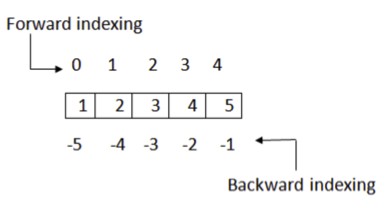

```python
numbers = list(range(5))
```

```python
numbers
```

```
[0, 1, 2, 3, 4]
```

```python
numbers[-2:]
```

```
[3, 4]
```

```python
numbers[3]
```

```
3
```

```python
numbers[-1]
```

```
4
```

```python
numbers[-2]
```

```
3
```

```python
numbers[0:2]
```

```
[0, 1]
```

```python
numbers[2:]
```

```
[2, 3, 4]
```

```python
numbers[: -3]
```

```
[0, 1]
```

# Operations

Some unexpected results

```python
odd_ints = list(range(1, 6, 2))
even_ints = list(range(0, 6, 2))
```

```python
odd_ints
```

```
[1, 3, 5]
```

```python
odd_ints[0:3:2]
```

```
[1, 5]
```

```python
odd_ints + [1]
```

```
[1, 3, 5, 1]
```

```python
odd_ints + [1]
```

```
[1, 3, 5, 1]
```

```python
odd_ints + even_ints
```

```
[1, 3, 5, 0, 2, 4]
```

```python
odd_ints * 2
```

```
[1, 3, 5, 1, 3, 5]
```

# Tuples

- A tuple is a sequence of immutable Python objects, i.e. once you specified a tuple you cannot change it.

```python
empty = ()
one_element = (5)
a = (10, 2801, 94)
b = ("panda", "monkey", "dog")
```

```python
len(a)
```

```
3
```

```python
b[1]
```

```
'monkey'
```

```python
a + b
```

```
(10, 2801, 94, 'panda', 'monkey', 'dog')
```

```python
"dog" in b
```

```
True
```

# Dictionaries

Dictionaries associate a key to a value. The value can be any non-mutable object (string, number, tuple).

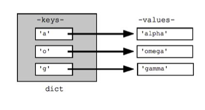

| **Operation** | **Speed** |
| --- | --- |
| Inserting | Fast |
| Deleting | Fast |
| Searching value | Slow |
| Searching key | Fast |

```python
released = {
    "Harry Potter and the Sorcerer's Stone": 1997,
    "Harry Potter and the Chamber of Secrets": 1998,
    "Harry Potter and the Prisoner of Azkaban": 1999,
    "Harry Potter and the Goblet of Fire": 2000,
    "Harry Potter and the Order of the Phoenix": 2003,
    "Harry Potter and the Half Blood Prince": 2005,
    "Harry Potter and the Deathly Hallows": 2007
}
```

```python
released["Harry Potter and the Sorcerer's Stone"]
```

```
1997
```

```python
len(released)
```

```
7
```

```python
released.keys()
```

```
dict_keys(["Harry Potter and the Sorcerer's Stone", 'Harry Potter and the Chamber of Secrets', 'Harry Potter and the Prisoner of Azkaban', 'Harry Potter and the Goblet of Fire', 'Harry Potter and the Order of the Phoenix', 'Harry Potter and the Half Blood Prince', 'Harry Potter and the Deathly Hallo…
```

```python
released.values()
```

```
dict_values([1997, 1998, 1999, 2000, 2003, 2005, 2007])
```

```python
released.items()
```

```
dict_items([("Harry Potter and the Sorcerer's Stone", 1997), ('Harry Potter and the Chamber of Secrets', 1998), ('Harry Potter and the Prisoner of Azkaban', 1999), ('Harry Potter and the Goblet of Fire', 2000), ('Harry Potter and the Order of the Phoenix', 2003), ('Harry Potter and the Half Blood Pr…
```

```python
for key in released.keys():
    print("The book \"{}\" was published in {}.".format(key, released[key]))
```

```
The book "Harry Potter and the Sorcerer's Stone" was published in 1997.
The book "Harry Potter and the Chamber of Secrets" was published in 1998.
The book "Harry Potter and the Prisoner of Azkaban" was published in 1999.
The book "Harry Potter and the Goblet of Fire" was published in 2000.
The book "Harry Potter and the Order of the Phoenix" was published in 2003.
The book "Harry Potter and the Half Blood Prince" was published in 2005.
The book "Harry Potter and the Deathly Hallows" was published in 2007.
```

# Lists vs. Tuples vs. Dictionaries

Use lists when:

1. You primarily want to append/ add elements into a collection and interate over them.
2. You do not plan to perform a lot of searches/deletions.

Use tuples when:

1. You do not plan to change the collection.
2. Return values in functions.

Use dictionaries when:

1. You have a logical key.
2. When you plan to do a lot of searches.
3. When you plan to do a lot of modifications.
4. You do not need slicing.

# Assignment vs. Copy - Basics

Assigning an object to another variable does not copy the object.

The new variable just points to the original.

```python
a = [1, 2, 3]
b = a
b[0] = 99
```

```python
b
```

```
[99, 2, 3]
```

```python
a
```

```
[99, 2, 3]
```

To edit/change without affecting the original variable, use copy!

```python
b = a.copy()
b[0] = 1
```

```python
b
```

```
[1, 2, 3]
```

```python
a
```

```
[99, 2, 3]
```

# Functions

```python
def my_function(string):
    """This function prints a message"""
    print(string)

my_function("Python is fun!")
```

```
Python is fun!
```

```python
def my_function(a, b):
    """This function returns the sum of a and b"""
    return a + b

a = my_function(50, 100)
a
```

```
150
```

```python
def my_function(a, b, print_also = False):
    """This function returns the sum of a and b"""
    result = a + b
    if print_also:
        print(result)
    return result


a_1 = my_function(50, 100)
a_2 = my_function(50, 100, print_also=True)
```

```
150
```

```python
a_1 == a_2
```

```
True
```

# NumPy

Etymologoy: **Num**erical **Py**thon. It is a library for array-oriented computing and foundation of the Python scientific stack. NumPy or numpy is suited for many applications (data-mining, machine-learning, deep-learning ...).

Numpy comes with several benefits:

1. It is fast (library is written in C/C++).
2. Easy to work with.
3. Support 2D and higher dimensional arrays (interesting for handling photos, satellite data etc.)
4. Perform operations across whole arrays (no need for loops).
5. Efficient built-in-functions to do data transformation, filtering, aggregation, statistics, linear algebra, common array algorithms, storing and reading data from disk.

The key to NumPy is the ndarray object, which is a N-dimensional array.

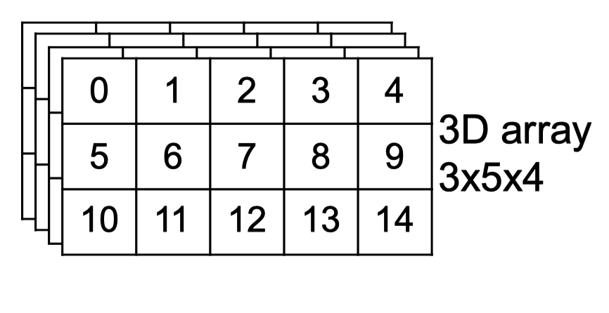

The differences between NumPy arrays and standard Python lists are

1. NumPy arrays have a fixed size.
2. NumPy array members must be of the same data type, called dtype.

Selection of supported data types

1. bool_,
2. int_,
3. float_,
4. complex_

The "_" is shorthand for defaults. The defaults are typicalyl inferred but sometimes you need to specify them yourself.

```python
import numpy as np
```

```python
np.array([1, 2, 3])
```

```
array([1, 2, 3])
```

```python
a1 = np.array([1, 2, 3])
a2 = np.arange(10)
a3 = np.zeros((2, 2))
a4 = np.random.random((3, 3))
a5 = np.ones((3,3))
a6 = np.eye(3)
```

# Indexing and Slicing

Options you have for indexing and slicing of the arrays

1. List or index in each direction.
2. Boolean mask
3. Specific indices

Example

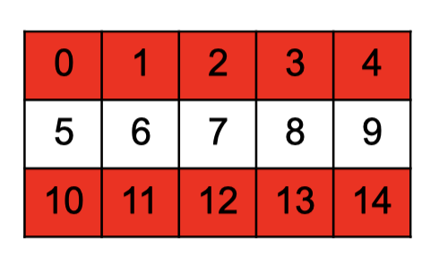

```python
array = np.arange(0, 15).reshape(3, -1)
```

```python
array[[0,2], :]
```

```
array([[ 0,  1,  2,  3,  4],
       [10, 11, 12, 13, 14]])
```

```python
array[[True, False, True], :]
```

```
array([[ 0,  1,  2,  3,  4],
       [10, 11, 12, 13, 14]])
```

For a specific item

```python
array[0,0]
```

```
0
```

There is an optional stride argument to select for example onle every other element in a row or column

```python
array[:: , ::2]
```

```
array([[ 0,  2,  4],
       [ 5,  7,  9],
       [10, 12, 14]])
```

Important: Array slices point to the original array. If you manipulate either the sliced array or the original array, the other one changes as well. If that is not desired, you have to use a copy.

# Array Operations

__

Basic operations are executed element-wise and the result is a new array.

```python
a = np.arange(5)
b = np.arange(5)
```

```python
a + b
```

```
array([0, 2, 4, 6, 8])
```

```python
a**3
```

[output not shown]

```python
10*np.sin(a)
```

```
array([ 0.        ,  8.41470985,  9.09297427,  1.41120008, -7.56802495])
```

```python
a*b
```

```
array([ 0,  1,  4,  9, 16])
```

```python
a > 2
```

```
array([False, False, False,  True,  True])
```

Other useful operations are: *abs, ceil, floor, mod, round, sign*

# Broadcasting - Idea

Pretty useful. Idea is that when the shapes of arrays do not permit element-wise operations of two numpy arrays, the arrays are stretched so that they can be combined element by element (some conditions need to be met though).

Example 1 from the docs:

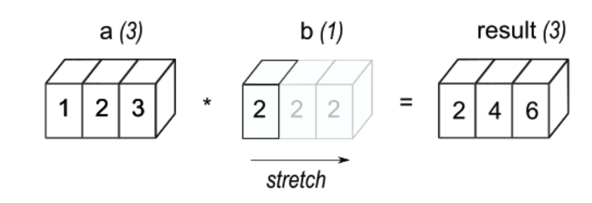

Example 2 from the docs:

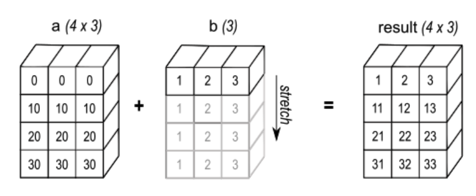

# Broadcasting - Rules

NumPy compares the shapes of two arrays element-wise. It starts with the rightmost dimensions and works its way left. Two dimensions are compatible when

1. they are equal, or
2. one of them is 1

# Reduction

Reduction functions - computing the mean, getting the min, max, argmin, argmax - can be performed over the whole array or over a single axis.

```python
a = np.arange(0, 15).reshape(3, -1)
a.sum()
```

```
105
```

```python
a.sum(axis = 0) # Computes sum for every column, i.e. reduces into the 0-th-dimension.
```

```
array([15, 18, 21, 24, 27])
```

```python
a.sum(axis = 1) # Computes sum for every row, i.e. reduces the first dimension.
```

```
array([10, 35, 60])
```

# NumPy Lifehacks

Transpose an array

```python
x = np.arange(0, 10).reshape(2, -1)
print(x)
```

```
[[0 1 2 3 4]
 [5 6 7 8 9]]
```

```python
b = x
b[0] = 1
print(x)
b = b.T
```

```
[[1 1 1 1 1]
 [5 6 7 8 9]]
```

Flatten an array

```python
x.ravel()
```

[output not shown]

Reshape an array

```python
x.reshape(5, -1)
```

[output not shown]

Stacking arrays

```python
a = np.array(10*np.random.random((2,2)), dtype = "int")
b = np.array(10*np.random.random((2,2)), dtype = "int")
```

To stack arrays vertically

```python
np.vstack((a, b))
```

```
array([[4, 0],
       [6, 8],
       [6, 5],
       [3, 1]])
```

To stack arrays horizontally

```python
np.hstack((a, b))
```

```
array([[4, 0, 6, 5],
       [6, 8, 3, 1]])
```